# Ford GoBike System Explanatory Data Analysis(EDA)

### Distribution of Duration(sec) per Start hour of the day for User type

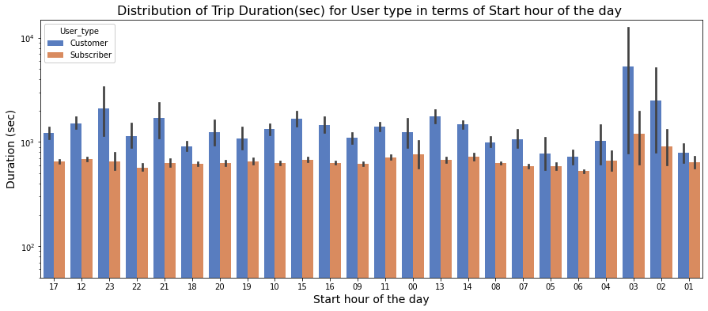

```python
plt.figure(figsize=[15,6])# set figure size
user_hour = sb.barplot(data =df_ford, x = 'start_hour', y = 'duration_sec', hue = 'user_type', palette = 'muted')# select bar chart from seaborn
user_hour.legend(loc = 2, framealpha = 1, title = 'User_type')# set legend format and position
plt.yscale('log')# log transformation to avoid the outlier.
plt.ylim([50, 15000]);# limit the duration to 15000 sec to get a clear view.
user_hour.set_xlabel('Start hour of the day', fontsize=14) #set label for x-axis
user_hour.set_ylabel('Duration (sec)', fontsize=14)#set label for x-axis
user_hour.set_title('Distribution of Trip Duration(sec) for User type in terms of Start hour of the day ', fontsize=16);#set title for chart
```

- for customer type 2 AM and 3 AM, the duration of biking is longer than any hour and than subscriber user.
- for subscriber user 2 AM, 3 AM the duration of biking is longer than any hour.

#### Distribution of Trip Duration(sec) per Age for Member gender.

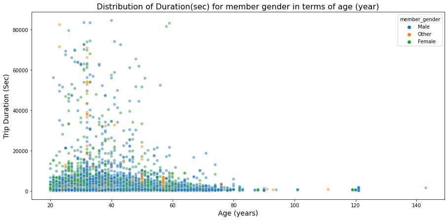

```python
fig = plt.figure(figsize = [15,7])
#scatter plot from seaborn library.
ax = sb.scatterplot(data=df_ford, y=df_ford['duration_sec'], x=df_ford['age'], hue='member_gender', alpha=0.5)
plt.ylabel('Trip Duration (Sec)', fontsize=14)#set label for y-axis.
plt.xlabel('Age (years)', fontsize=14); #set label for x-axis.
plt.title('Distribution of Duration(sec) for member gender in terms of age (year)', fontsize=16);#set title for chart
```

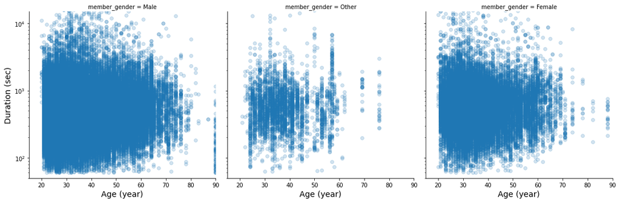

```python
# limit the duration to 15000 sec to get a clear view and age to 90 years
age_genders = sb.FacetGrid(data =df_ford, col = 'member_gender', ylim= [50, 15000],xlim = [15, 90],col_wrap =5, height = 5 )
age_genders.map(plt.scatter, 'age', 'duration_sec', alpha=.2)
age_genders.set_xlabels('Age (year)', fontsize=14)#set label for x-axis
age_genders.set_ylabels('Duration (sec)', fontsize=14)#set label for y-axis
plt.yscale('log')# log transformation to avoid the outlier.
```

Other gender with 55 years have a large peak in trip duration (sec).

#### Duartion(sec)of bike trip per member_gender in terms of start day of the week

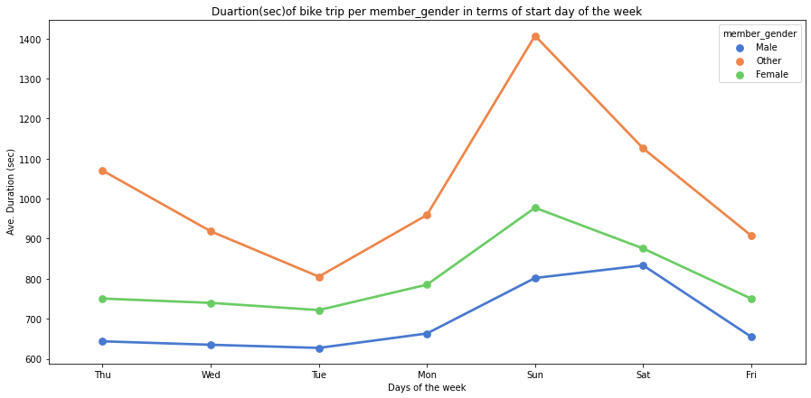

```python
# Distribution of Duartion(sec) for bike trip per member_gender in terms of start day of the week
fig = plt.figure(figsize = [15,7])
sb.pointplot(data = df_ford, x = 'start_day_week', y = 'duration_sec', hue = 'member_gender', ci=None, palette = 'muted')
plt.title('Duartion(sec)of bike trip per member_gender in terms of start day of the week')
plt.ylabel(' Ave. Duration (sec)')
plt.xlabel('Days of the week');
```

##### other gender >female >male in Ave. Duration (sec) in weekends rather than weekdays.

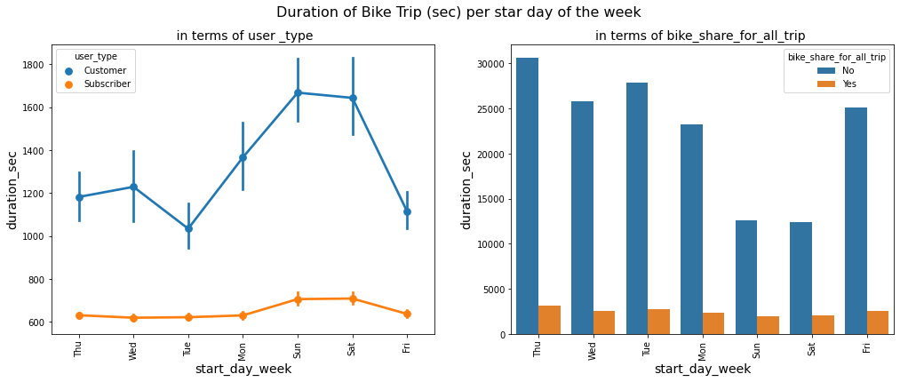

```python
# Distribution of Duration of Bike Trip (sec) per star day of the week in terms of user _type
plt.figure(figsize=(17,6))
plt.suptitle('Duration of Bike Trip (sec) per star day of the week', fontsize=16)
plt.subplot(1,2,1)
sb.pointplot(data=df_ford, x='start_day_week', y='duration_sec', hue='user_type')
plt.title(" in terms of user _type", fontsize=14);
plt.xlabel('start_day_week', fontsize=14);#set x-axis label
plt.ylabel('duration_sec', fontsize=14),#set y-axis label
plt.xticks(rotation=90);
plt.subplot(1,2,2)## Distribution of Duration of Bike Trip (sec) per star day of the week in terms of bike_share_for_all_trip
sb.countplot(data=df_ford,x='start_day_week',hue='bike_share_for_all_trip')
plt.title("in terms of bike_share_for_all_trip ", fontsize=14);
plt.xlabel('start_day_week', fontsize=14);#set x-axis label
plt.ylabel('duration_sec', fontsize=14),#set y-axis label
plt.xticks(rotation=90);
```

#### Distribution of Trip Duration(sec) per Start hour of the day for Star day of the week

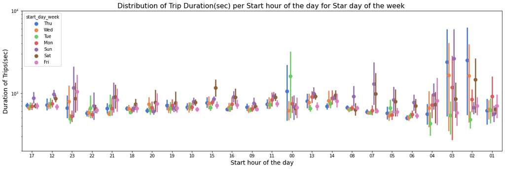

```python
plt.figure(figsize=[20,6])
sb.pointplot(data = df_ford, x = 'start_hour', y = 'duration_sec', hue = 'start_day_week',dodge = 0.5, linestyles = "",palette='muted')
plt.yscale('log')# log transformation to avoid the outlier.
plt.ylim([200, 10000]);#  limit the duration to 12000 sec to get a clear view.
plt.xlabel('Start hour of the day', fontsize=14);
plt.ylabel('Duration of Trips(sec)', fontsize=14);
plt.title('Distribution of Trip Duration(sec) per Start hour of the day for Star day of the week ', fontsize=16);
```

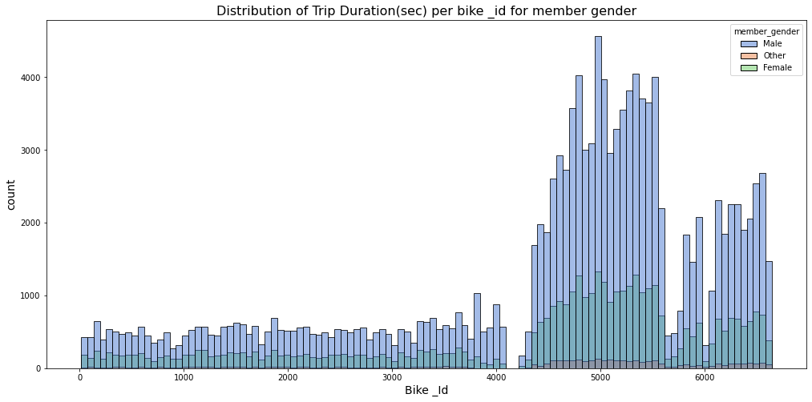

```python
plt.figure(figsize=[17,8])
sb.histplot(data=df_ford,x=df_ford['bike_id'],hue='member_gender',palette='muted');
plt.xlabel('Bike _Id', fontsize=14);#set x-axis label
plt.ylabel('count', fontsize=14),#set y-axis label
plt.title('Distribution of Trip Duration(sec) per bike _id for member gender', fontsize=16);#set title for chart
```

###### Talk about some of the relationships you observed in this part of the investigation. Were there features that strengthened each other in terms of looking at your feature(s) of interest?

>

> I observed that though the number of trips duration (sec) is higher in percentage for male for female and other gender, also other gender has a peak at nearly the age of 55 years for the higher duration(sec).

> During all days of week the median of trip duration_sec for customer user type is higher than that for subscriber user type.Customer Users have high trip duration than Subscriber.

> Other gender >female >male in Ave. Duration (sec) in weekends rather than weekdays.

> Subscribers mainly hire a bike during weekdays, but a significantly higher trip duration during weekend days by Customers.

> During all days of week the median of trip duration_sec for customer user type is higher than that for subscriber user type.Customer Users have high trip duration than Subscriber.

> the duration of biking is longer, for customer user @ 2 AM and 3 AM, than any hour and than subscriber user.The duration of biking is longer than any hour for subscriber user@ 2 AM, 3 AM .

> A bike ridding is very popular among subscriber user rather than customer user which may point to special ponus or free rides for user subscribed in bike share system.

> It is appeared that Bike with id above 4000 is frequent used.

### Were there any interesting or surprising interactions between features?

>

> subscriber who use bike share for all trip is about 9.9% from all users

> Customers usage during the weekendsrather than subscriber.

> customers didn't use bike share at all